# Mad extension?!

# 2.6 arules

```
The **apriori algorithm** is often used as a way of selecting ‘interesting’ rules. It will calculate all the support, confidence and lift values for the item/itemset combinations of your dataset and will return those with support values greater than a pre-defined threshold value set by the user.

Read up on the `arules` and `arulesViz` packages, which make use of the ‘apriori’ algorithm http://www.salemmarafi.com/code/market-basket-analysis-with-r/comment-page-1/
```

Notes:

- we are looking for items that are typically bought together, more often than if they were independent / no association.
  - An example: sometimes cheese is bought with kitchen roll, but the probability of cheese and loo roll == prob(cheese) * prob(loo roll), i.e. these items are independent, and there’s no evidence that cheese and loo roll complement each other in the basket. However, cheese and wine are bought together more often than is likely from simple probability (p(cheese AND wine) > p(cheese)*p(wine)) - which means that they are associated
  - Not just two items, but sets of items, e.g. if cheese and wine, likely to also buy crackers, grapes, etc. More likely than if these were unrelated items. Algorithm looks for these patterns - where do items or groups of items (sets) appaear more often than is likly by chance (independent probabilities)?

```r
library(arules)
library(arulesViz)
```

*Note these libraries mask some functions, e.g. dplyr::recode*

```r
class(Groceries)
```

```
[1] "transactions"
attr(,"package")
[1] "arules"
```

```r
class(Groceries)
```

```
[1] "transactions"
attr(,"package")
[1] "arules"
```

```r
class(transactions)
```

```
[1] "spec_tbl_df" "tbl_df"      "tbl"         "data.frame"
```

## reformat transactions

First, transactions data needs to be in the right format for arules, needs to be an `itemMatrix` (transactions, associations) - homework file tells how to do this:

```r
transactions_reformat <- transactions %>%
  select(invoice_no, description) %>%
  na.omit()

write_csv(transactions_reformat, "transactions_reformat.csv")

apriori_format <- read.transactions("transactions_reformat.csv", format = "single", sep = ",", header = TRUE, cols = c("invoice_no", "description"))
```

```r
apriori_format
```

```
transactions in sparse format with
 786 transactions (rows) and
 2470 items (columns)
```

```r
inspect(head(apriori_format))
```

```
    items                                                        transactionID
[1] {CREAM CUPID HEARTS COAT HANGER,
     GLASS STAR FROSTED T-LIGHT HOLDER,
     KNITTED UNION FLAG HOT WATER BOTTLE,
     RED WOOLLY HOTTIE WHITE HEART.,
     SET 7 BABUSHKA NESTING BOXES,
     WHITE HANGING HEART T-LIGHT HOLDER,
     WHITE METAL LANTERN}                                               536365
[2] {HAND WARMER RED POLKA DOT,
     HAND WARMER UNION JACK}                                            536366
[3] {ASSORTED COLOUR BIRD ORNAMENT,
     BOX OF 6 ASSORTED COLOUR TEASPOONS,
     BOX OF VINTAGE ALPHABET BLOCKS,
     BOX OF VINTAGE JIGSAW BLOCKS,
     DOORMAT NEW ENGLAND,
     FELTCRAFT PRINCESS CHARLOTTE DOLL,
     HOME BUILDING BLOCK WORD,
     IVORY KNITTED MUG COSY,
     LOVE BUILDING BLOCK WORD,
     POPPYS PLAYHOUSE BEDROOM
536367,POPPYS PLAYHOUSE KITCHEN,
     RECIPE BOX WITH METAL HEART}                                       536367
[4] {BLUE COAT RACK PARIS FASHION,
     JAM MAKING SET WITH JARS,
     RED COAT RACK PARIS FASHION,
     YELLOW COAT RACK PARIS FASHION}                                    536368
[5] {BATH BUILDING BLOCK WORD}                                          536369
[6] {ALARM CLOCK BAKELIKE GREEN,
     ALARM CLOCK BAKELIKE PINK,
     ALARM CLOCK BAKELIKE RED,
     CHARLOTTE BAG DOLLY GIRL DESIGN,
     CIRCUS PARADE LUNCH BOX,
     INFLATABLE POLITICAL GLOBE,
     LUNCH BOX I LOVE LONDON,
     MINI JIGSAW CIRCUS PARADE,
     MINI JIGSAW SPACEBOY,
     MINI PAINT SET VINTAGE,
     PANDA AND BUNNIES STICKER SHEET,
     POSTAGE,
     RED TOADSTOOL LED NIGHT LIGHT,
     ROUND SNACK BOXES SET OF4 WOODLAND,
     SET 2 TEA TOWELS I LOVE LONDON,
     SET/2 RED RETROSPOT TEA TOWELS,
     SPACEBOY LUNCH BOX,
     STARS GIFT TAPE,
     VINTAGE HEADS AND TAILS CARD GAME,
     VINTAGE SEASIDE JIGSAW PUZZLES}                                    536370
```

This format concatenates all the items in an invoice into one cell, so each row is the contents of the basket and the basket id (invoice number).

Note, we are using format = “single” because our original df has 1 row = 1 item, with 1 invoice split across multiple rows. Format = “basket” is for data where 1 row = 1 basket and items are already listed together, separated by whatever sep =.

There are 786 transactions in this format - not all 1406 baskets from the raw data. **Q: Why is this?** Are some sets duplicated in our original data, and we only see the first invoice_no for this set?

## check why fewer transactions, see stock code

```r
transactions %>%
  summarise(across(.cols = everything(),
                   .fns = ~ sum(is.na(.x))))
```

| invoice_no | stock_code | description | invoice_date | unit_price | customer_id | country |
| --- | --- | --- | --- | --- | --- | --- |
| 0 | 0 | 114 | 0 | 0 | 10043 | 0 |

114 NAs in description. Maybe use stock code instead?

```r
transactions_reformat_stock <- transactions %>%
  select(invoice_no, stock_code) %>%
  na.omit()

write_csv(transactions_reformat_stock, "transactions_reformat_stock.csv")

apriori_format_stock <- read.transactions("transactions_reformat_stock.csv", format = "single", sep = ",", header = TRUE, cols = c("invoice_no", "stock_code"))
```

```r
apriori_format_stock
```

```
transactions in sparse format with
 1406 transactions (rows) and
 2645 items (columns)
```

Now there are all 1406 transactions.

```r
# make a lookup list of item description by stock_code
item_lookup <- transactions %>%
  select(stock_code, description) %>%
  distinct()

item_lookup
```

| stock_code | description |
| --- | --- |
| 85123A | WHITE HANGING HEART T-LIGHT HOLDER |
| 71053 | WHITE METAL LANTERN |
| 84406B | CREAM CUPID HEARTS COAT HANGER |
| 84029G | KNITTED UNION FLAG HOT WATER BOTTLE |
| 84029E | RED WOOLLY HOTTIE WHITE HEART. |
| 22752 | SET 7 BABUSHKA NESTING BOXES |
| 21730 | GLASS STAR FROSTED T-LIGHT HOLDER |
| 22633 | HAND WARMER UNION JACK |
| 22632 | HAND WARMER RED POLKA DOT |
| 84879 | ASSORTED COLOUR BIRD ORNAMENT |

[output cut: 990 more lines]

```r
item_lookup %>%
  filter(is.na(description))
```

| stock_code | description |
| --- | --- |
| 22139 | NA |
| 21134 | NA |
| 22145 | NA |
| 37509 | NA |
| 85226A | NA |
| 85044 | NA |
| 20950 | NA |
| 37461 | NA |
| 84670 | NA |
| 21777 | NA |

[output cut: 93 more lines]

2,747 items by stock code, 103 of which have no description.

Look at most frequently bought items (by stock_code)

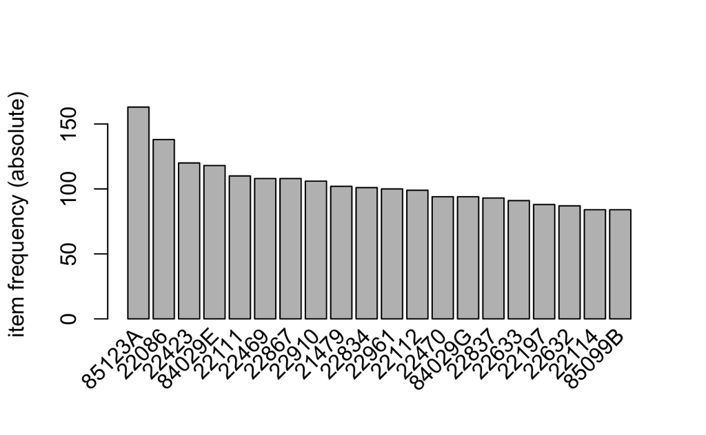

```r
item_lookup %>%
  filter(stock_code %in% c("85123A", "22086", "22423", "84029E", "22111"))
```

| stock_code | description |
| --- | --- |
| 85123A | WHITE HANGING HEART T-LIGHT HOLDER |
| 84029E | RED WOOLLY HOTTIE WHITE HEART. |
| 22086 | PAPER CHAIN KIT 50'S CHRISTMAS |
| 22111 | SCOTTIE DOG HOT WATER BOTTLE |
| 22423 | REGENCY CAKESTAND 3 TIER |
| 22423 | faulty |

Note that one stock code has 2 descriptions. Check if this is true for others:

```r
item_lookup %>%
  summarise(duplicate_codes = n(), .by = stock_code) %>%
  filter(duplicate_codes > 1)
```

| stock_code | duplicate_codes |
| --- | --- |
| 22632 | 2 |
| 21777 | 2 |
| 22114 | 2 |
| 22139 | 3 |
| 22778 | 2 |
| 21324 | 2 |
| 22963 | 2 |
| 17091A | 2 |
| 20966 | 2 |
| 21743 | 2 |

[output cut: 89 more lines]

Ok, so stock code is not a unique identifier.

Check it was ok to use stock_code as unique id for items A and B in earlier analysis:

```r
item_lookup %>%
  filter(description %in% c("HEART OF WICKER SMALL", "LARGE CAKE TOWEL PINK SPOTS"))
```

| stock_code | description |
| --- | --- |
| 22469 | HEART OF WICKER SMALL |
| 21110 | LARGE CAKE TOWEL PINK SPOTS |

Yes - these stock codes are unique and 1:1 with item description.

## itemFrequencyPlot

Revert to using item descriptions for analysis to keep things simple - use `apriori_format`:

[figure not shown]

[figure not shown]

```r
itemFrequencyPlot(apriori_format,topN=50,type="absolute")
```

Look at the top association rules.

## apriori() to make rules

```r
rules <- apriori(apriori_format, parameter = list(supp = 0.01, conf = 0.8))
```

```
Apriori

Parameter specification:
```

|  | confidence | minval | smax | arem | aval | originalSupport | maxtime | support | minlen | maxlen | target | ext |
| --- | --- | --- | --- | --- | --- | --- | --- | --- | --- | --- | --- | --- |
|  | 0.8 | 0.1 | 1 | none | FALSE | TRUE | 5 | 0.01 | 1 | 10 | rules | TRUE |

```
Algorithmic control:
```

|  | filter | tree | heap | memopt | load | sort | verbose |
| --- | --- | --- | --- | --- | --- | --- | --- |
|  | 0.1 | TRUE | TRUE | FALSE | TRUE | 2 | TRUE |

```
Absolute minimum support count: 7

set item appearances ...[0 item(s)] done [0.00s].
set transactions ...[2470 item(s), 786 transaction(s)] done [0.00s].
sorting and recoding items ... [686 item(s)] done [0.00s].
creating transaction tree ... done [0.00s].
checking subsets of size 1 2 3 4 5 6 7 8 9 10
```

```
 done [0.01s].
writing ... [54237 rule(s)] done [0.02s].
creating S4 object  ... done [0.01s].
```

Playing with minimum support:

- 0.1 -> no rules
- 0.05 -> no rules
- 0.01 -> 54,237 rules
- 0.03 -> 0 rules
- 0.02 -> 5 rules: jam jar lids, bath sponges, alarm clocks, popcorn holders – all the same item type but in different colours / shapes / sizes
- 0.005 -> took a while to run…
- 0.008 -> 507,069 rules, quick to run

Let’s stick with min supp = 0.01, min conf = 0.8

|  | lhs |  | rhs | support | confidence | coverage | lift | count |
| --- | --- | --- | --- | --- | --- | --- | --- | --- |
| [1] | {HAND WARMER RED POLKA DOT} | => | {HAND WARMER UNION JACK} | 0.01017812 | 0.8888889 | 0.01145038 | 14.86525 | 8 |
| [2] | {SILK PURSE BABUSHKA BLUE} | => | {SILK PURSE BABUSHKA RED} | 0.01145038 | 0.8181818 | 0.01399491 | 53.59091 | 9 |
| [3] | {SET/6 RED SPOTTY PAPER PLATES} | => | {SET/6 RED SPOTTY PAPER CUPS} | 0.01017812 | 0.8888889 | 0.01145038 | 63.51515 | 8 |
| [4] | {MONSTERS STENCIL CRAFT} | => | {HAPPY STENCIL CRAFT} | 0.01145038 | 0.9000000 | 0.01272265 | 50.52857 | 9 |
| [5] | {ALPHABET STENCIL CRAFT} | => | {HAPPY STENCIL CRAFT} | 0.01017812 | 0.8000000 | 0.01272265 | 44.91429 | 8 |

Note from help file: *“The default behavior is to mine rules with minimum support of 0.1, minimum confidence of 0.8, maximum of 10 items (maxlen), and a maximal time for subset checking of 5 seconds (maxtime).”*

## Summary & inspect rules

```r
summary(rules)
```

```
set of 54237 rules

rule length distribution (lhs + rhs):sizes
    2     3     4     5     6     7     8     9    10
  127  2520  6096 10446 13032 11375  6914  2907   820

   Min. 1st Qu.  Median    Mean 3rd Qu.    Max.
   2.00    5.00    6.00    6.12    7.00   10.00

summary of quality measures:
    support          confidence        coverage            lift            count
 Min.   :0.01018   Min.   :0.8000   Min.   :0.01018   Min.   : 7.312   Min.   : 8.000
 1st Qu.:0.01018   1st Qu.:1.0000   1st Qu.:0.01018   1st Qu.:17.915   1st Qu.: 8.000
 Median :0.01018   Median :1.0000   Median :0.01018   Median :29.111   Median : 8.000
 Mean   :0.01041   Mean   :0.9784   Mean   :0.01068   Mean   :34.050   Mean   : 8.183
 3rd Qu.:0.01018   3rd Qu.:1.0000   3rd Qu.:0.01018   3rd Qu.:48.369   3rd Qu.: 8.000
 Max.   :0.02799   Max.   :1.0000   Max.   :0.03308   Max.   :78.600   Max.   :22.000

mining info:
```

|  | data | ntransactions | support | confidence | call |
| --- | --- | --- | --- | --- | --- |
|  | apriori_format | 786 | 0.01 | 0.8 | apriori(data = apriori_format, parameter = list(supp = 0.01, conf = 0.8)) |

This summary info tells us:

- In the 786 transactions, the algorithm has found 54,237 rules of sizes 2 (1:1) to 10 (lhs set of 9 : rhs set of 1) with mode set length of 6 (5 in set on lhs : 1 on rhs)
- These rules have support 0.01018 (our min was 0.01) to 0.02799 <- the max is quite high off the central and 3rd quartile measures (all ~0.01), which indicates it may be unusual.
- Confidence ranges from 0.8 (our set minimum threshold) to 1 (which is the maximum possible, 100% likelihood) - and the quartiles and central measures indicate at least 75% of the rules have confidence == 1.
- Lift ranges from 7.312 to 78.60, with 50% of the data between 17.915 and 48.369.

|  | lhs |  | rhs | support | confidence | coverage | lift | count |
| --- | --- | --- | --- | --- | --- | --- | --- | --- |
| [1] | {HAND WARMER RED POLKA DOT} | => | {HAND WARMER UNION JACK} | 0.01017812 | 0.8888889 | 0.01145038 | 14.86525 | 8 |
| [2] | {SILK PURSE BABUSHKA BLUE} | => | {SILK PURSE BABUSHKA RED} | 0.01145038 | 0.8181818 | 0.01399491 | 53.59091 | 9 |
| [3] | {SET/6 RED SPOTTY PAPER PLATES} | => | {SET/6 RED SPOTTY PAPER CUPS} | 0.01017812 | 0.8888889 | 0.01145038 | 63.51515 | 8 |
| [4] | {MONSTERS STENCIL CRAFT} | => | {HAPPY STENCIL CRAFT} | 0.01145038 | 0.9000000 | 0.01272265 | 50.52857 | 9 |
| [5] | {ALPHABET STENCIL CRAFT} | => | {HAPPY STENCIL CRAFT} | 0.01017812 | 0.8000000 | 0.01272265 | 44.91429 | 8 |
| [6] | {SET OF 6 T-LIGHTS SANTA} | => | {SET OF 6 T-LIGHTS SNOWMEN} | 0.01145038 | 0.9000000 | 0.01272265 | 39.30000 | 9 |
| [7] | {NATURAL SLATE CHALKBOARD LARGE} | => | {NATURAL SLATE HEART CHALKBOARD} | 0.01017812 | 0.8000000 | 0.01272265 | 13.97333 | 8 |
| [8] | {VINTAGE BILLBOARD LOVE/HATE MUG} | => | {WHITE METAL LANTERN} | 0.01017812 | 0.8000000 | 0.01272265 | 28.58182 | 8 |
| [9] | {VINTAGE BILLBOARD LOVE/HATE MUG} | => | {RETRO COFFEE MUGS ASSORTED} | 0.01017812 | 0.8000000 | 0.01272265 | 24.18462 | 8 |
| [10] | {HERB MARKER MINT} | => | {HERB MARKER THYME} | 0.01017812 | 0.8888889 | 0.01145038 | 69.86667 | 8 |

## Rules sorted

We need to sort the table! (Says so in recommended web link to read: http://www.salemmarafi.com/code/market-basket-analysis-with-r/comment-page-1/)

```r
# top 20 by confidence
rules_conf<-sort(rules, by="confidence", decreasing=TRUE)
inspect(rules_conf[1:20])
```

```
     lhs                                       rhs                                      support confidence   coverage      lift count
[1]  {HERB MARKER MINT}                     => {HERB MARKER BASIL}                   0.01145038          1 0.01145038 71.454545     9
[2]  {HERB MARKER THYME}                    => {HERB MARKER PARSLEY}                 0.01272265          1 0.01272265 78.600000    10
[3]  {HERB MARKER PARSLEY}                  => {HERB MARKER THYME}                   0.01272265          1 0.01272265 78.600000    10
[4]  {HERB MARKER THYME}                    => {HERB MARKER BASIL}                   0.01272265          1 0.01272265 71.454545    10
[5]  {HERB MARKER PARSLEY}                  => {HERB MARKER BASIL}                   0.01272265          1 0.01272265 71.454545    10
[6]  {HERB MARKER ROSEMARY}                 => {HERB MARKER BASIL}                   0.01272265          1 0.01272265 71.454545    10
[7]  {BLACK MINI TAPE MEASURE}              => {SANDWICH BATH SPONGE}                0.01145038          1 0.01145038 34.173913     9
[8]  {GLASS STAR FROSTED T-LIGHT HOLDER,
      WHITE METAL LANTERN}                  => {KNITTED UNION FLAG HOT WATER BOTTLE} 0.01017812          1 0.01017812 17.863636     8
[9]  {GLASS STAR FROSTED T-LIGHT HOLDER,
      KNITTED UNION FLAG HOT WATER BOTTLE}  => {WHITE METAL LANTERN}                 0.01017812          1 0.01017812 35.727273     8
[10] {GLASS STAR FROSTED T-LIGHT HOLDER,
      WHITE METAL LANTERN}                  => {RED WOOLLY HOTTIE WHITE HEART.}      0.01017812          1 0.01017812 11.909091     8
[11] {GLASS STAR FROSTED T-LIGHT HOLDER,
      WHITE METAL LANTERN}                  => {WHITE HANGING HEART T-LIGHT HOLDER}  0.01017812          1 0.01017812  9.139535     8
[12] {GLASS STAR FROSTED T-LIGHT HOLDER,
      KNITTED UNION FLAG HOT WATER BOTTLE}  => {RED WOOLLY HOTTIE WHITE HEART.}      0.01017812          1 0.01017812 11.909091     8
[13] {GLASS STAR FROSTED T-LIGHT HOLDER,
      KNITTED UNION FLAG HOT WATER BOTTLE}  => {WHITE HANGING HEART T-LIGHT HOLDER}  0.01017812          1 0.01017812  9.139535     8
[14] {CREAM CUPID HEARTS COAT HANGER,
      KNITTED UNION FLAG HOT WATER BOTTLE}  => {RED WOOLLY HOTTIE WHITE HEART.}      0.01017812          1 0.01017812 11.909091     8
[15] {CREAM CUPID HEARTS COAT HANGER,
      RED WOOLLY HOTTIE WHITE HEART.}       => {KNITTED UNION FLAG HOT WATER BOTTLE} 0.01017812          1 0.01017812 17.863636     8
[16] {WOOD S/3 CABINET ANT WHITE FINISH,
      WOODEN PICTURE FRAME WHITE FINISH}    => {WOOD 2 DRAWER CABINET WHITE FINISH}  0.01272265          1 0.01272265 28.071429    10
[17] {RED WOOLLY HOTTIE WHITE HEART.,
      WOOD S/3 CABINET ANT WHITE FINISH}    => {WOOD 2 DRAWER CABINET WHITE FINISH}  0.01017812          1 0.01017812 28.071429     8
[18] {KNITTED UNION FLAG HOT WATER BOTTLE,
      WOOD 2 DRAWER CABINET WHITE FINISH}   => {RED WOOLLY HOTTIE WHITE HEART.}      0.01399491          1 0.01399491 11.909091    11
[19] {VINTAGE BILLBOARD LOVE/HATE MUG,
      WHITE METAL LANTERN}                  => {RETRO COFFEE MUGS ASSORTED}          0.01017812          1 0.01017812 30.230769     8
[20] {RETRO COFFEE MUGS ASSORTED,
      VINTAGE BILLBOARD LOVE/HATE MUG}      => {WHITE METAL LANTERN}                 0.01017812          1 0.01017812 35.727273     8
```

We know from the summary that most of the rules have confidence = 1, so this is a bit of a misleading ordering category.

```r
# top 20 by lift
rules_lift<-sort(rules, by="lift", decreasing=TRUE)
inspect(rules_lift[1:20])
```

```
     lhs                         rhs                          support confidence   coverage     lift count
[1]  {HERB MARKER THYME}      => {HERB MARKER PARSLEY}     0.01272265  1.0000000 0.01272265 78.60000    10
[2]  {HERB MARKER PARSLEY}    => {HERB MARKER THYME}       0.01272265  1.0000000 0.01272265 78.60000    10
[3]  {HERB MARKER MINT,
      HERB MARKER THYME}      => {HERB MARKER PARSLEY}     0.01017812  1.0000000 0.01017812 78.60000     8
[4]  {HERB MARKER MINT,
      HERB MARKER PARSLEY}    => {HERB MARKER THYME}       0.01017812  1.0000000 0.01017812 78.60000     8
[5]  {HERB MARKER ROSEMARY,
      HERB MARKER THYME}      => {HERB MARKER PARSLEY}     0.01145038  1.0000000 0.01145038 78.60000     9
[6]  {HERB MARKER PARSLEY,
      HERB MARKER ROSEMARY}   => {HERB MARKER THYME}       0.01145038  1.0000000 0.01145038 78.60000     9
[7]  {HERB MARKER BASIL,
      HERB MARKER THYME}      => {HERB MARKER PARSLEY}     0.01272265  1.0000000 0.01272265 78.60000    10
[8]  {HERB MARKER BASIL,
      HERB MARKER PARSLEY}    => {HERB MARKER THYME}       0.01272265  1.0000000 0.01272265 78.60000    10
[9]  {HERB MARKER BASIL,
      HERB MARKER MINT,
      HERB MARKER THYME}      => {HERB MARKER PARSLEY}     0.01017812  1.0000000 0.01017812 78.60000     8
[10] {HERB MARKER BASIL,
      HERB MARKER MINT,
      HERB MARKER PARSLEY}    => {HERB MARKER THYME}       0.01017812  1.0000000 0.01017812 78.60000     8
[11] {HERB MARKER BASIL,
      HERB MARKER ROSEMARY,
      HERB MARKER THYME}      => {HERB MARKER PARSLEY}     0.01145038  1.0000000 0.01145038 78.60000     9
[12] {HERB MARKER BASIL,
      HERB MARKER PARSLEY,
      HERB MARKER ROSEMARY}   => {HERB MARKER THYME}       0.01145038  1.0000000 0.01145038 78.60000     9
[13] {SANDWICH BATH SPONGE,
      WOODLAND CHARLOTTE BAG} => {BLACK MINI TAPE MEASURE} 0.01017812  0.8888889 0.01145038 77.62963     8
[14] {HERB MARKER MINT}       => {HERB MARKER BASIL}       0.01145038  1.0000000 0.01145038 71.45455     9
[15] {HERB MARKER BASIL}      => {HERB MARKER MINT}        0.01145038  0.8181818 0.01399491 71.45455     9
[16] {HERB MARKER THYME}      => {HERB MARKER BASIL}       0.01272265  1.0000000 0.01272265 71.45455    10
[17] {HERB MARKER BASIL}      => {HERB MARKER THYME}       0.01272265  0.9090909 0.01399491 71.45455    10
[18] {HERB MARKER PARSLEY}    => {HERB MARKER BASIL}       0.01272265  1.0000000 0.01272265 71.45455    10
[19] {HERB MARKER BASIL}      => {HERB MARKER PARSLEY}     0.01272265  0.9090909 0.01399491 71.45455    10
[20] {HERB MARKER ROSEMARY}   => {HERB MARKER BASIL}       0.01272265  1.0000000 0.01272265 71.45455    10
```

A different set of top 20, note there are 4 rules with confidence < 1 in this top 20 (from 0.82 upwards).

All but one of the top 20 rules (with the greatest lift) are sets of herb markers; the other one is the combo of a bath sponge, bag and mini tape measure.

```r
# top 20 by support (i.e. probability of buying individual items - so the items most frequently bought in general)
rules_support <- sort(rules, by="support", decreasing=TRUE)
inspect(rules_support[1:20])
```

|  | lhs |  | rhs | support | confidence | coverage | lift | count |
| --- | --- | --- | --- | --- | --- | --- | --- | --- |
| [1] | {LARGE POPCORN HOLDER} | => | {SMALL POPCORN HOLDER} | 0.02798982 | 0.9166667 | 0.03053435 | 15.01042 | 22 |
| [2] | {ALARM CLOCK BAKELIKE ORANGE} | => | {ALARM CLOCK BAKELIKE GREEN} | 0.02671756 | 0.8076923 | 0.03307888 | 16.27811 | 21 |
| [3] | {JAM JAR WITH GREEN LID} | => | {JAM MAKING SET PRINTED} | 0.02290076 | 0.8571429 | 0.02671756 | 12.24935 | 18 |
| [4] | {JAM JAR WITH PINK LID} | => | {JAM JAR WITH GREEN LID} | 0.02035623 | 0.9411765 | 0.02162850 | 35.22689 | 16 |
| [5] | {APPLE BATH SPONGE} | => | {SANDWICH BATH SPONGE} | 0.02035623 | 0.8000000 | 0.02544529 | 27.33913 | 16 |
| [6] | {JAM JAR WITH PINK LID} | => | {JAM MAKING SET PRINTED} | 0.01908397 | 0.8823529 | 0.02162850 | 12.60963 | 15 |
| [7] | {STRAWBERRY BATH SPONGE} | => | {APPLE BATH SPONGE} | 0.01781170 | 0.8235294 | 0.02162850 | 32.36471 | 14 |
| [8] | {DINOSAURS WRITING SET} | => | {BALLOONS WRITING SET} | 0.01526718 | 0.8571429 | 0.01781170 | 35.45865 | 12 |
| [9] | {MAGIC DRAWING SLATE DOLLY GIRL} | => | {MAGIC DRAWING SLATE SPACEBOY} | 0.01526718 | 0.9230769 | 0.01653944 | 48.36923 | 12 |
| [10] | {MAGIC DRAWING SLATE SPACEBOY} | => | {MAGIC DRAWING SLATE DOLLY GIRL} | 0.01526718 | 0.8000000 | 0.01908397 | 48.36923 | 12 |

[output cut: 10 more lines]

Range of support in the top 20 rules here is 0.01399 (i.e. 1.4% of transactions involve *?? item on rhs ??: small glass heart trinket pot*) to 0.0279… (i.e. 2.8% of transactions involve *small popcorn holder*)

## 1:1 rules

What if I wanted to find which individual items are frequently bought together, not sets in LHS:

```r
rules_1to1 <- rules <- apriori(apriori_format, parameter = list(supp = 0.01, conf = 0.8, maxlen=2))
```

```
Apriori

Parameter specification:
```

|  | confidence | minval | smax | arem | aval | originalSupport | maxtime | support | minlen | maxlen | target | ext |
| --- | --- | --- | --- | --- | --- | --- | --- | --- | --- | --- | --- | --- |
|  | 0.8 | 0.1 | 1 | none | FALSE | TRUE | 5 | 0.01 | 1 | 2 | rules | TRUE |

```
Algorithmic control:
```

|  | filter | tree | heap | memopt | load | sort | verbose |
| --- | --- | --- | --- | --- | --- | --- | --- |
|  | 0.1 | TRUE | TRUE | FALSE | TRUE | 2 | TRUE |

```
Absolute minimum support count: 7

set item appearances ...[0 item(s)] done [0.00s].
set transactions ...[2470 item(s), 786 transaction(s)] done [0.00s].
sorting and recoding items ... [686 item(s)] done [0.00s].
creating transaction tree ... done [0.00s].
checking subsets of size 1 2
```

```
 done [0.00s].
writing ... [127 rule(s)] done [0.00s].
creating S4 object  ... done [0.00s].
```

127 1:1 rules.

```r
summary(rules_1to1)
```

```
set of 127 rules

rule length distribution (lhs + rhs):sizes
  2
127

   Min. 1st Qu.  Median    Mean 3rd Qu.    Max.
      2       2       2       2       2       2

summary of quality measures:
    support          confidence        coverage            lift           count
 Min.   :0.01018   Min.   :0.8000   Min.   :0.01145   Min.   :11.03   Min.   : 8.000
 1st Qu.:0.01018   1st Qu.:0.8000   1st Qu.:0.01272   1st Qu.:19.38   1st Qu.: 8.000
 Median :0.01145   Median :0.8333   Median :0.01272   Median :30.76   Median : 9.000
 Mean   :0.01212   Mean   :0.8573   Mean   :0.01416   Mean   :35.68   Mean   : 9.528
 3rd Qu.:0.01272   3rd Qu.:0.9000   3rd Qu.:0.01527   3rd Qu.:51.16   3rd Qu.:10.000
 Max.   :0.02799   Max.   :1.0000   Max.   :0.03308   Max.   :78.60   Max.   :22.000

mining info:
```

|  | data | ntransactions | support | confidence | call |
| --- | --- | --- | --- | --- | --- |
|  | apriori_format | 786 | 0.01 | 0.8 | apriori(data = apriori_format, parameter = list(supp = 0.01, conf = 0.8, maxlen = 2)) |

Of these 127 1:1 rules

- support range includes same min and max as for full list of rules (above)
- confidence: 3rd quartile ≠ 1 so there are higher proportion of rules with confidence < 1 than above
- lift: higher min and 3rd quartile, same max, as above - indicates lift distribution is shifted higher in this 1:1 set

```r
# top 20 rules by confidence
rules1to1_conf <- sort(rules, by="confidence", decreasing=TRUE)
inspect(rules1to1_conf[1:20])
```

|  | lhs |  | rhs | support | confidence | coverage | lift | count |
| --- | --- | --- | --- | --- | --- | --- | --- | --- |
| [1] | {HERB MARKER MINT} | => | {HERB MARKER BASIL} | 0.01145038 | 1.0000000 | 0.01145038 | 71.45455 | 9 |
| [2] | {HERB MARKER THYME} | => | {HERB MARKER PARSLEY} | 0.01272265 | 1.0000000 | 0.01272265 | 78.60000 | 10 |
| [3] | {HERB MARKER PARSLEY} | => | {HERB MARKER THYME} | 0.01272265 | 1.0000000 | 0.01272265 | 78.60000 | 10 |
| [4] | {HERB MARKER THYME} | => | {HERB MARKER BASIL} | 0.01272265 | 1.0000000 | 0.01272265 | 71.45455 | 10 |
| [5] | {HERB MARKER PARSLEY} | => | {HERB MARKER BASIL} | 0.01272265 | 1.0000000 | 0.01272265 | 71.45455 | 10 |
| [6] | {HERB MARKER ROSEMARY} | => | {HERB MARKER BASIL} | 0.01272265 | 1.0000000 | 0.01272265 | 71.45455 | 10 |
| [7] | {BLACK MINI TAPE MEASURE} | => | {SANDWICH BATH SPONGE} | 0.01145038 | 1.0000000 | 0.01145038 | 34.17391 | 9 |
| [8] | {JAM JAR WITH PINK LID} | => | {JAM JAR WITH GREEN LID} | 0.02035623 | 0.9411765 | 0.02162850 | 35.22689 | 16 |
| [9] | {MAGIC DRAWING SLATE DOLLY GIRL} | => | {MAGIC DRAWING SLATE SPACEBOY} | 0.01526718 | 0.9230769 | 0.01653944 | 48.36923 | 12 |
| [10] | {COFFEE MUG DOG + BALL DESIGN} | => | {COFFEE MUG CAT + BIRD DESIGN} | 0.01399491 | 0.9166667 | 0.01526718 | 42.38235 | 11 |

[output cut: 10 more lines]

```r
# top 20 rules by lift
rules1to1_lift <- sort(rules, by="lift", decreasing=TRUE)
inspect(rules1to1_lift[1:20])
```

|  | lhs |  | rhs | support | confidence | coverage | lift | count |
| --- | --- | --- | --- | --- | --- | --- | --- | --- |
| [1] | {HERB MARKER THYME} | => | {HERB MARKER PARSLEY} | 0.01272265 | 1.0000000 | 0.01272265 | 78.60000 | 10 |
| [2] | {HERB MARKER PARSLEY} | => | {HERB MARKER THYME} | 0.01272265 | 1.0000000 | 0.01272265 | 78.60000 | 10 |
| [3] | {HERB MARKER MINT} | => | {HERB MARKER BASIL} | 0.01145038 | 1.0000000 | 0.01145038 | 71.45455 | 9 |
| [4] | {HERB MARKER BASIL} | => | {HERB MARKER MINT} | 0.01145038 | 0.8181818 | 0.01399491 | 71.45455 | 9 |
| [5] | {HERB MARKER THYME} | => | {HERB MARKER BASIL} | 0.01272265 | 1.0000000 | 0.01272265 | 71.45455 | 10 |
| [6] | {HERB MARKER BASIL} | => | {HERB MARKER THYME} | 0.01272265 | 0.9090909 | 0.01399491 | 71.45455 | 10 |
| [7] | {HERB MARKER PARSLEY} | => | {HERB MARKER BASIL} | 0.01272265 | 1.0000000 | 0.01272265 | 71.45455 | 10 |
| [8] | {HERB MARKER BASIL} | => | {HERB MARKER PARSLEY} | 0.01272265 | 0.9090909 | 0.01399491 | 71.45455 | 10 |
| [9] | {HERB MARKER ROSEMARY} | => | {HERB MARKER BASIL} | 0.01272265 | 1.0000000 | 0.01272265 | 71.45455 | 10 |
| [10] | {HERB MARKER BASIL} | => | {HERB MARKER ROSEMARY} | 0.01272265 | 0.9090909 | 0.01399491 | 71.45455 | 10 |

[output cut: 10 more lines]

In top 20 by confidence, top 7 are the ones with confidence = 1 (herb markers, mini tape measure with a bath sponge); then there are more items of the same type where two different designs/colours have been bought together (e.g. coffee mugs with different designs). Also, toast-its are bought with ceramic trinket boxes (1:1 rule for same toast it with two different designs of trinket box), and white goose feather christmas tree has been bought with several designs of trinket pot/boxes.

In top 20 by lift, we again have the herb markers, which dominate all the high lift scores.

## arulesViz

### associations2igraph

Visualise the association rules:

[figure not shown]

There are too many associations to make sense of here

Let’s look at the 20 herb marker 1:1 associations:

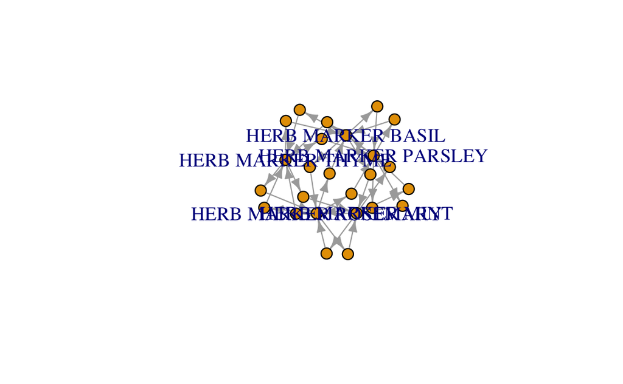

```r
nodes_graph_top20_1to1_lift <- associations2igraph(rules1to1_lift[1:20])

plot(nodes_graph_top20_1to1_lift)
```

This graph suggests there are some herb markers that are more commonly bought in pairs/sets than others, those with the most arrows pointing inwards to the, e.g. basil, thyme, mint, rosemary, parsley.

Let’s look at the top 20 by support in the full rules:

[figure not shown]

```r
library("tidygraph")
as_tbl_graph(nodes_graph_top20_1to1_lift)
```

```
# A tbl_graph: 25 nodes and 40 edges
#
# A bipartite simple graph with 1 component
#
# A tibble: 25 × 9
  name   label                index  type support confidence coverage  lift count
  <chr>  <chr>                <int> <dbl>   <dbl>      <dbl>    <dbl> <dbl> <int>
1 1038   HERB MARKER BASIL     1038     1 NA              NA  NA       NA      NA
2 1040   HERB MARKER MINT      1040     1 NA              NA  NA       NA      NA
3 1041   HERB MARKER PARSLEY   1041     1 NA              NA  NA       NA      NA
4 1042   HERB MARKER ROSEMARY  1042     1 NA              NA  NA       NA      NA
5 1043   HERB MARKER THYME     1043     1 NA              NA  NA       NA      NA
6 assoc1 NA                       1     2  0.0127          1   0.0127  78.6    10
# ℹ 19 more rows
# ℹ Use `print(n = ...)` to see more rows
#
# A tibble: 40 × 2
   from    to
  <int> <int>
1     5     6
2     3     7
3     2     8
# ℹ 37 more rows
# ℹ Use `print(n = ...)` to see more rows
```

*Don’t understand this table view*

### ruleExplorer shiny app

```r
ruleExplorer(apriori_format)
```

[output not shown]

This returns a shiny app, requires “shinythemes” package.

Can play with support and confidence thresholds, and order by confidence, lift etc in the resulting rules.

e.g. raising min conf to 0.9 reduces rules to ~6000, more manageable

# Summary

Can use association rules to manually calculate the support, confidence and lift for defined item pairings.

Can use the apriori algorithm, with `arules` and `arulesViz` packages, to look at transactions data and find associations between items - in particular, useful for naive exploration and looking for associations between set of items and an individual item. to use this:

- first, reformat transactions data using `read.transactions()`
- using this reformatted data, you can make a frequency graph for individual items using `itemFrequencyPlot()` - limit to top 10-20 most bought items
- also using reformatted data, use `apriori()` and provide args for minimum support and confidence thresholdto find association rules: e.g. `rules <- apriori(data, parameter = list(supp = 0.01, conf = 0.8))`
  - can also specify maxlen in apriori parameters to limit number of items in a set in lhs (where maxlen = n limits lhs set size to n-1)
- summary() to get summary statistics, and inspect(x[1:n]) to see the top n, for which you can specify ordering rule (by support, confidence, lift…)
- arulesViz has functions to:
  - `ruleExplorer()`: produces a shiny app with dynamic parameter args to create rules table and explore by sorting by columns and searching within the table
  - `x <- associations2igraph()` then `plot(x)` : draw a graph with nodes being items and edges being association directions (i think?? No edges means no items are in more than 1 association?).

For more info:

- docs for arules: https://cran.r-project.org/web/packages/arules/readme/README.html ; http://mhahsler.github.io/arules/
- docs for arulesViz: https://github.com/mhahsler/arulesViz